# Assignment: Spatial Analysis in R

Gaby Garcia

## OVERVIEW

This exercise accompanies the lessons in Environmental Data Analytics (ENV872L) on spatial analysis.

## Directions

1. Change “Student Name” on line 3 (above) with your name.
2. Use the lesson as a guide. It contains code that can be modified to complete the assignment.
3. Work through the steps, **creating code and output** that fulfill each instruction.
4. Be sure to **answer the questions** in this assignment document. Space for your answers is provided in this document and is indicated by the “>” character. If you need a second paragraph be sure to start the first line with “>”. You should notice that the answer is highlighted in green by RStudio.
5. When you have completed the assignment, **Knit** the text and code into a single HTML file.
6. After Knitting, please submit the completed exercise (HTML file) to the dropbox in Sakai. Please add your last name into the file name (e.g., “Fay_A09_SpatialAnalysis.pdf”) prior to submission.

# 1. Prepare the workspace

- Import: tidyverse, sf, and leaflet

```r
library(tidyverse)
library(sf)
library(leaflet)
library(dplyr)
```

# 2. Read filtered county features into an sf dataframe and plot

In this exercise, we will be exploring stream gage height data in Nebraska, as there’s been recent floods there. First, we will import from the US Counties  
shapefile we’ve used in lab lessons, filtering it this time for just Nebraska counties. Nebraska’s state FIPS code is `31` (as North Carolina’s was `37`).

- Read the cb_2017_us_county_20m.shp shapefile into an sf dataframe
- Filter for Nebraska counties (State FIPS = 31)
- Show the dataset’s coordinate reference system
- Plot the records as a map (in any format)

## Read in Counties shapefile into an sf dataframe, filtering for just Nebraska counties

```r
setwd("~/Desktop/Environmental Data Analytics/Environmental_Data_Analytics/Data/Spatial")

CountiesShapefile<- st_read('cb_2017_us_county_20m.shp') %>%
  filter(STATEFP == 31) #Filter for just Nebraska Counties
```

## Set Theme

```r
gabytheme <- theme_bw(base_size = 14) +
  theme(plot.title=element_text(face="bold", size="16", color="Indianred3", hjust=0.5),
        axis.title=element_text(face="bold.italic", size=11, color="black"),
axis.text = element_text(face="bold", size=10, color = "black"),
panel.background=element_rect(fill="lightgray", color="darkblue"),
panel.border = element_rect(color = "black", size = 2),
legend.position = "top", legend.background = element_rect(fill="white", color="black"),
            legend.key = element_rect(fill="transparent", color="NA"))
theme_set(gabytheme)
```

## Reveal the Coordinate Reference System (crs) of the counties features

```r
st_crs(CountiesShapefile)
```

```
## Coordinate Reference System:
##   EPSG: 4269
##   proj4string: "+proj=longlat +datum=NAD83 +no_defs"
```

## Plot the records as a map (in any format)

```r
library(mapview)
mapviewOptions(basemaps = c('OpenStreetMap','Esri.WorldImagery','Stamen.Toner','Stamen.Watercolor')) #Set Base Maps
mapView(CountiesShapefile)
```

[interactive chart not shown]

> QUESTION: What is the EPSG code of the Counties dataset? Using http://spatialreference.org, is this a geographic or a projected coordinate system? (Or, does this CRS use angular or planar coordinate units?) To what datum is this CRS associated?  
> ANSWER: The EPSG code is 4269. This is a Geographic Coordinate system and uses angular coordinate units. This CRS uses the “North American Datum 1983”.

# 3. Read in gage locations csv as a dataframe, then display the column names it contains

Next we’ll read in some USGS/NWIS gage location data I’ve added to the `Data/Raw` folder. These are in the `NWIS_SiteInfo_NE_RAW.csv` file. (See `NWIS_SiteInfo_NE_RAW.README.txt` for more info on this datset.) * Read the NWIS_SiteInfo_NE_RAW.csv file into a standard dataframe * Display the column names of this dataset

## Read in gage locations csv as a dataframe

```r
setwd("~/Desktop/Environmental Data Analytics/Environmental_Data_Analytics/Data/Raw")
NWIS<-read.csv('NWIS_SiteInfo_NE_RAW.csv')
```

## Reveal the names of the columns

```r
colnames(NWIS)
```

```
## [1] "site_no"            "station_nm"         "site_tp_cd"
## [4] "dec_lat_va"         "dec_long_va"        "coord_acy_cd"
## [7] "dec_coord_datum_cd"
```

> QUESTION: What columns in the dataset contain the x and y coordinate values, respectively? ANSWER: dec_lat_va contains the y coordinate values and dec_long_va contains the x coordinate values.

# 4. Convert the gage locations dataframe to an sf dataframe of points

- These data use the same coordinate reference system as the counties dataset (crs=4269)
- Display the column names of the resulting sf dataframe

## Convert to sf dataframe

```r
NWISsf<- st_as_sf(NWIS,coords = c('dec_long_va','dec_lat_va'),crs=4269)
```

## Reveal the structure

```r
str(NWISsf)
```

```
## Classes 'sf' and 'data.frame':   175 obs. of  6 variables:
##  $ site_no           : int  6453600 6454100 6461500 6463500 6463720 6465500 6465700 6466400 6466500 6478518 ...
##  $ station_nm        : Factor w/ 175 levels " BIG SANDY CR AT ALEXANDRIA, NE",..: 117 85 87 70 86 88 162 7 8 24 ...
##  $ site_tp_cd        : Factor w/ 1 level "ST": 1 1 1 1 1 1 1 1 1 1 ...
##  $ coord_acy_cd      : Factor w/ 6 levels "1","5","F","H",..: 6 6 6 6 6 6 6 6 6 6 ...
##  $ dec_coord_datum_cd: Factor w/ 1 level "NAD83": 1 1 1 1 1 1 1 1 1 1 ...
##  $ geometry          :sfc_POINT of length 175; first list element:  'XY' num  -98.2 42.8
##  - attr(*, "sf_column")= chr "geometry"
##  - attr(*, "agr")= Factor w/ 3 levels "constant","aggregate",..: NA NA NA NA NA
##   ..- attr(*, "names")= chr  "site_no" "station_nm" "site_tp_cd" "coord_acy_cd" ...
```

> QUESTION: What new field(s) appear in the sf dataframe created? What field(s), if any, disappeared? ANSWER: A “Geometry” column appeared in the new sf dataframe (which incorporated the longitude and latitude columns), while the dec_long_va (longitude) and dec_lat_va (latitude) columns were deleted.

# 5. Read in the gage height data and join the site location data to it.

And finally, we want to attach some gage height data to our site locations. I’ve constructed a csv file listing many of the Nebraska gage sites, by station name and site number along with stream gage heights (in meters) recorded during the recent flood event. This file is titled `NWIS_SiteFlowData_NE_RAW.csv` and is found in the Data/Raw folder.

- Read this dataset in as a dataframe.
- Join our site information (already imported above) to these gage height data.
- The `site_no` and `station_nm` can both serve as joining attributes.
- Construct this join so that the result only includes records where both tables have data.
- Show the column names in this resulting dataframe
- Once joined, we will again have to convert this product (a dataframe) into a spatial dataframe. Do that.

## Read in the data

```r
setwd("~/Desktop/Environmental Data Analytics/Environmental_Data_Analytics/Data/Raw")
NWISFlow<-read.csv('NWIS_SiteFlowData_NE_RAW.csv')
```

## Show the column names

```r
colnames(NWISFlow)
```

```
## [1] "site_no"    "station_nm" "date"       "gage_ht"
```

## Join location data to it

```r
NWISJoin <- NWIS %>% ###counties spatial features
  left_join(y = NWISFlow,by = ('site_no'))  ###left table comes first
```

## Remove NA’s from DataFrame

```r
NWISJoinClean<-na.omit(NWISJoin)
```

## Show column names in Resulting Cleaned Dataframe

```r
colnames(NWISJoinClean)
```

```
##  [1] "site_no"            "station_nm.x"       "site_tp_cd"
##  [4] "dec_lat_va"         "dec_long_va"        "coord_acy_cd"
##  [7] "dec_coord_datum_cd" "station_nm.y"       "date"
## [10] "gage_ht"
```

## Convert back to sf dataframe-now will have only one geometry column.

```r
NWISJoinCleansf<- st_as_sf(NWISJoinClean,coords = c('dec_long_va','dec_lat_va'),crs=4269)
```

# 6. Use `ggplot` to plot the gage locations on top of the counties

- Plot the different datasets in different colors

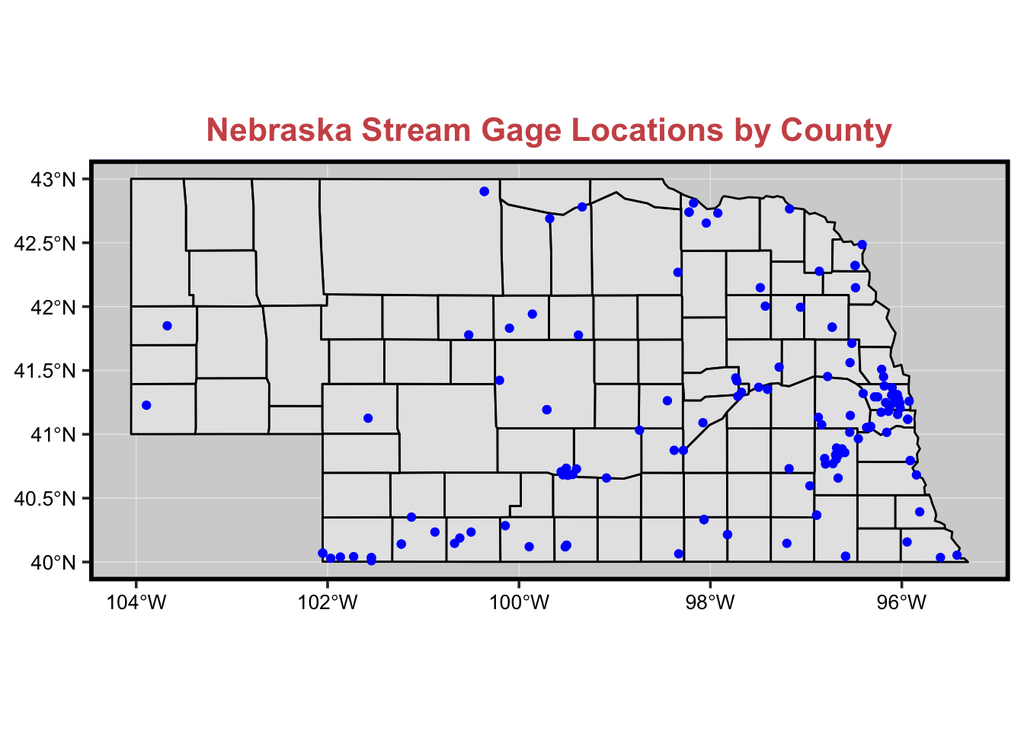

```r
GagePlot<-ggplot() +
  geom_sf(data = CountiesShapefile, col='black') + ###Counties
  geom_sf(data=NWISJoinCleansf, col='blue') +
  labs(title="Nebraska Stream Gage Locations by County")###Gage Locations

 GagePlot
```

# 7. Map the pattern of gage height data

Now we can examine where the flooding appears most acute by visualizing gage heights spatially. * Plot the gage sites on top of counties * Show the magnitude of gage height by color, shape, other visualization technique.

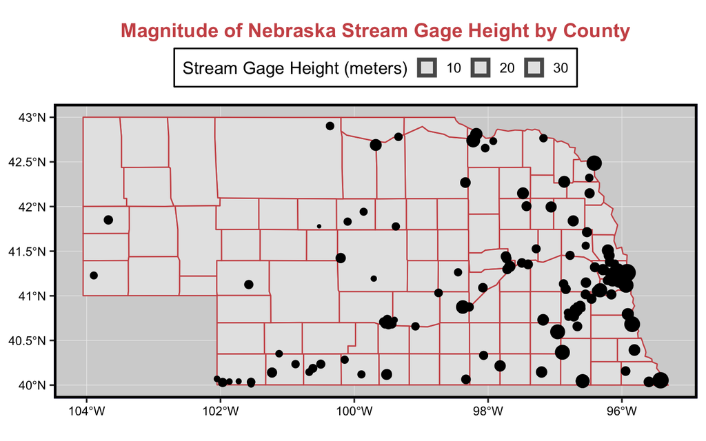

```r
library(ggplot2)
GagePlot2<-ggplot() +
 geom_sf(data=CountiesShapefile, color='indianred3') +
  geom_sf(data=NWISJoinCleansf, aes(size=gage_ht))+
  labs(title="Magnitude of Nebraska Stream Gage Height by County", size='Stream Gage Height (meters)')

GagePlot2
```

## SPATIAL ANALYSIS

Up next we will do some spatial analysis with our data. To prepare for this, we should transform our data into a projected coordinate system. We’ll choose UTM Zone 14N (EPGS = 32614).

# 8. Transform the counties and gage site datasets to UTM Zone 14N

- Transform each dataset to crs 32614
- Using ggplot, plot the data so that each can be seen as different colors

## View existing Coordinate Reference Systems

```r
st_crs(CountiesShapefile)
```

```
## Coordinate Reference System:
##   EPSG: 4269
##   proj4string: "+proj=longlat +datum=NAD83 +no_defs"
```

```r
st_crs(NWISJoinCleansf)
```

```
## Coordinate Reference System:
##   EPSG: 4269
##   proj4string: "+proj=longlat +ellps=GRS80 +towgs84=0,0,0,0,0,0,0 +no_defs"
```

## Transform the counties and gage location datasets to UTM Zone 14

```r
CountiesShapefileUTM<- st_transform(CountiesShapefile,crs=32614)
NWISJoinCleansfUTM<-st_transform(NWISJoinCleansf, crs=32614)
```

## Check to see that Dataframes are in Projected Coordinate Systems

```r
st_crs(CountiesShapefileUTM)
```

```
## Coordinate Reference System:
##   EPSG: 32614
##   proj4string: "+proj=utm +zone=14 +datum=WGS84 +units=m +no_defs"
```

```r
st_crs(NWISJoinCleansfUTM)
```

```
## Coordinate Reference System:
##   EPSG: 32614
##   proj4string: "+proj=utm +zone=14 +datum=WGS84 +units=m +no_defs"
```

### The st_crs function specifies what coordinate reference system the geometry uses.

### EPSG is a petroleum group=4269 refers to a specific coordinate system

### proj4string tells us the projection name “longlat”, the datum name(NAD83), and no other definitions

## Plot the data

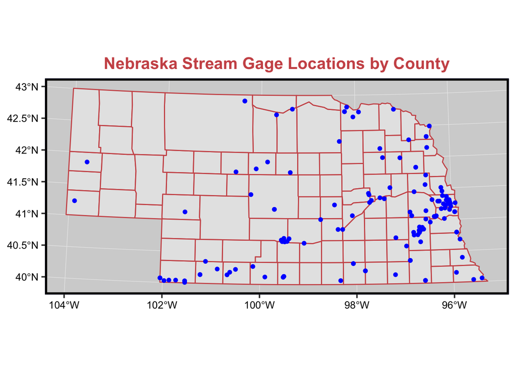

```r
GagePlotUTM<-ggplot() +
  geom_sf(data = CountiesShapefileUTM, col='indianred3') + ###Counties
  geom_sf(data=NWISJoinCleansfUTM, col='blue')+
  labs(title="Nebraska Stream Gage Locations by County")

 GagePlotUTM
```

> QUESTION: The shape of Nebraska should look a bit different than the one created in Step 5? Why?

> ANSWER: Using st_transform, we transformed the dataframes from a geographical coordinate system to a projected coordinate system. Our data went from spherical coordinates (angles) to projected coordinates (lengths).PCS additionally require information on how the surface of this sphere is projected onto a plane and the location of the origin of the coordinate system.

# 9. Select the gages falling within a given county

Now let’s zoom into a particular county and examine the gages located there. * Import the HUC8 dataset (`NE_HUC8s_prj.shp` in the Datafolder) * Select Lancaster county from your county sf dataframe * Select the gage sites falling `within` that county * Remember you’ll have to create a mask and then apply that mask * Create a plot showing: * all Nebraska counties, * the selected county, * and the gage sites in that county ***

```r
setwd("~/Desktop/Environmental Data Analytics/Environmental_Data_Analytics/Data/Spatial")
huc8<- st_read('cb_2017_us_county_20m.shp') ##Read US Counties shapefile into a SF dataframe
huc8utm<- st_transform(huc8, c=26914)%>%filter(COUNTYFP == 109)%>%filter(NAME =="Lancaster") ##Filter for Lancaster County, NE
```

## Spatial selection: Select Lancaster County in which user provided lat/long pair is found

```r
#User coordinates
userLat2 = 40.7
userLng2 = -96.9
```

userLat2 = 40.697948 userLng2 = -96.913493 ##Create a simple features point geometry from the point

```r
Lancastersfp<- st_point(c(userLng2,userLat2))
```

## Create a simple features column from the point geometry object

```r
Lancastersfc<- st_sfc(Lancastersfp, crs = 4269) ##from point, he's creating a spatial feature column, which is the coordinates + the spatial references
```

## Transform geographical coordinate system to a UTM coordinate system (Projected)

```r
Lancastersfctransformed<-st_transform(Lancastersfc, crs = st_crs(CountiesShapefileUTM))
```

## Create a Boolean Mask

```r
LancasterMask<- st_intersects(CountiesShapefileUTM ,
                            Lancastersfctransformed,
                            sparse = FALSE) #The `sparse` option returns a Boolean mask
```

## Filter the counties dataset using the Boolean Mask

```r
LancasterCounty<-CountiesShapefileUTM[LancasterMask,]%>%
  filter(NAME == 'Lancaster') ###using matrix subset, returns the counties that are TRUE-->Lancaster
```

## Create a Plot showing:

- all Nebraska counties,
- the selected county,
- and the gage sites in that county

## Determine which Gage Sites are in Lancaster County

```r
mapView(LancasterCounty) + NWISJoinCleansfUTM
```

[interactive chart not shown]

###The Gage Site Numbers in Lancaster County are: 6803000, 6803080, 6803093, 6803170, 6803300, 6803502, 6803495, 6803500, 6803510, 6803513, 6803520, 6803530.

## Filter All Nebraska Gage Sites to only choose Gage Sites in Lancaster County

```r
NWISJoinCleansfUTMLancaster<-filter(NWISJoinCleansfUTM, site_no%in% c('6803000','6803080', '6803093', '6803170', '6803300', '6803502','6803495','6803500','6803510','6803513','6803520','6803530'))
```

## Plot

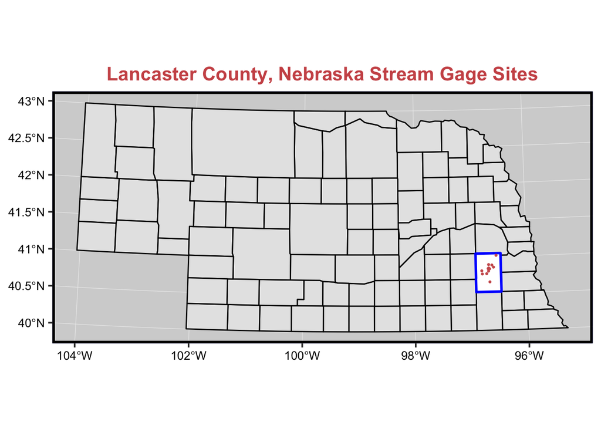

```r
NebraskaGageSites<-ggplot() +
geom_sf(data=CountiesShapefileUTM, color = 'black')  +
geom_sf(data = LancasterCounty, color='blue', size=1, fill='white') +
  geom_sf(data=NWISJoinCleansfUTMLancaster, col='indianred', size=0.5)+
  labs(title="Lancaster County, Nebraska Stream Gage Sites", color="indianred")

NebraskaGageSites
```

# 10. Tag each gage site with the name of the county in which it falls

A spatial join (`st_join`) allows us to assign the attributes of an overlapping feature onto a another feature. We will use to to assign each gage location the attributes of the county in which it is located. * Spatially join the county features to the gage height features * Display the list of fields in the resulting dataset * Map the gage locations, * Include county boundaries * Displaying each gage locations county “NAME” as a different color. * Display each gage size proportional to its “gage_ht” value

## Join features

```r
CountiesandGages<-st_join(NWISJoinCleansfUTM,CountiesShapefileUTM,join=st_intersects)
```

### PUT NWIS DATAFRAME FIRST (left) TO MAINTAIN GEOMETRY

## Transform into UTM Coordinates

```r
CountiesandGagesTransformed<-st_transform(CountiesandGages,crs=32614)
```

## Remove NA’s

```r
CountiesandGagesTransformed2<-na.omit(CountiesandGagesTransformed)
```

## Display list of fields in the resulting dataset

```r
names(CountiesandGagesTransformed2)
```

```
##  [1] "site_no"            "station_nm.x"       "site_tp_cd"
##  [4] "coord_acy_cd"       "dec_coord_datum_cd" "station_nm.y"
##  [7] "date"               "gage_ht"            "STATEFP"
## [10] "COUNTYFP"           "COUNTYNS"           "AFFGEOID"
## [13] "GEOID"              "NAME"               "LSAD"
## [16] "ALAND"              "AWATER"             "geometry"
```

## Map Gage Locations

- Include county boundaries
- Displaying each gage locations county “NAME” as a different color.
- Display each gage size proportional to its “gage_ht” value

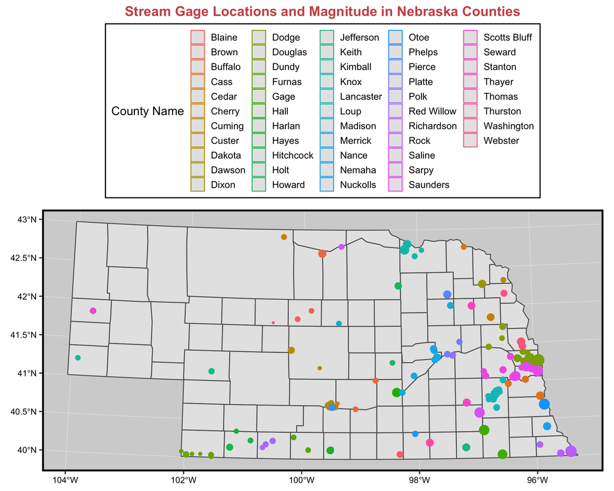

```r
CountiesandGagesPlot<-ggplot() +
geom_sf(data=CountiesShapefileUTM)  +  ###county boundaries
geom_sf(data=CountiesandGagesTransformed2, aes(color=NAME, size=gage_ht)) +
labs(title='Stream Gage Locations and Magnitude in Nebraska Counties', color='County Name')+
guides(size=FALSE)  ###remove Legend for Size Aesthetic b/c it's not accurate and not showing magnitude differences
CountiesandGagesPlot
```

# 11. Summarize data by county

Finally, we’ll summarize our gage height data by county and then display each county by it’s mean gage height. * Group the spatially joined gage location/county dataset on the county name * Compute mean gage height * Join (non-spatially) this result to our county sf dataframe * Prior to joining, you’ll need to drop the geometry column from the gage locations * To do this, see the `st_drop_geometry` function

- Plot the counties showing mean gage heights for each county
- Not all counties will have data

## Group and Summarize

```r
#Group and summarize

GageSum<-CountiesandGagesTransformed %>%
  group_by(NAME) %>%
  summarise(gage_ht = mean(gage_ht))
```

## Drop Geometry Column from the Gage Locations

```r
SumGagessimple<-st_drop_geometry(GageSum)
```

## Join gage Height Sum Dataframe to Counties Shapefile UTM

```r
GageSumJoined<-SumGagessimple%>%left_join(y=CountiesShapefileUTM, by="NAME")
```

## Plot

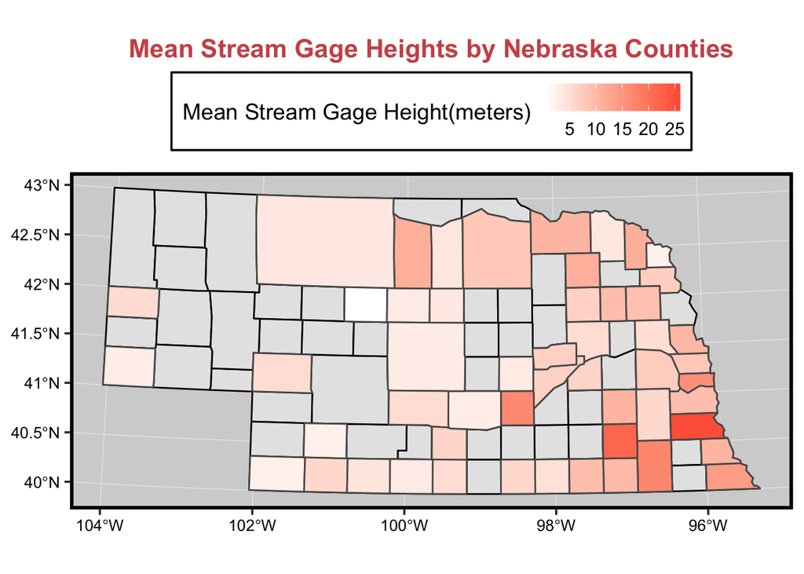

```r
GageDatabyCountyPlot<-ggplot() +
geom_sf(data=CountiesShapefileUTM, color="black")  +  ###county boundaries
geom_sf(data=GageSumJoined, aes(fill=gage_ht))+
 scale_fill_gradient(name="Mean Stream Gage Height(meters)", low="white", high="tomato")+
  labs(title='Mean Stream Gage Heights by Nebraska Counties')

GageDatabyCountyPlot
```